# R Notebook

# Load libraries

```r
library(affy)
library(affyPLM)
library(sva)
library(AnnotationDbi)
library(hgu133plus2.db)
library(tidyverse)
```

## read the data, caclulate normalized expression

what does rma actually do? normalize across probesets?

```r
data_files<-list.files('/projectnb/bf528/users/group9/project1/samples/',full=TRUE)
#data_files<-list.files('/project/bf528/project_1/data/GSE39582/CEL_files/samples/',full=TRUE)
affydata<-ReadAffy(filenames=data_files,compress=TRUE)
normalized_expression<-rma(affydata)
```

```
Background correcting
Normalizing
Calculating Expression
```

# Calculating RLE and NUSE by using fitPLM

Computing Relative Log Expression (RLE) and Normalized Unscaled Standard Error (NUSE), following this link: https://www.bioconductor.org/packages/release/bioc/vignettes/affyPLM/inst/doc/QualityAssess.pdf

## options used in fitPLM are:

normalize: If TRUE performs quanitle normalization where each array is rank ordered (each array tests multiple genes and so gene expression is ordered), average values for most-expressed, 2nd most expressed etc are caclulated across arrays. Then the array readout is replaced by what you would expect for a gene expression of that rank background: If TRUE background correct using RMA background correction. This corrects for the noise in the readout due to light from nearby cells in the microarray, and other such background noise

```r
Probe_Set <- fitPLM(affydata,normalize=TRUE, background=TRUE) #this fits probe-level models to all of the probesets.
```

first we visualize residuals

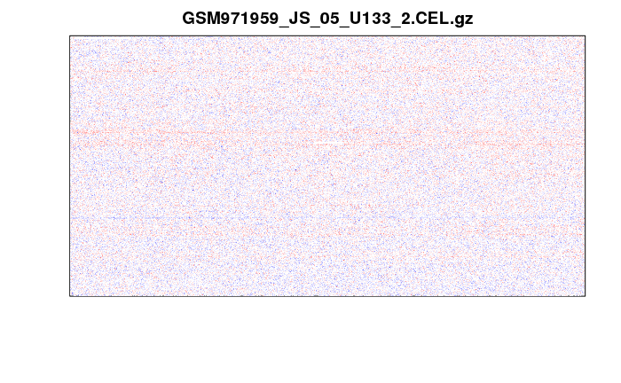

```r
image(Probe_Set,which=2, type="resids")#visualized residuals to check data quality
```

## now we calculate RLE(Relative Log Expression)

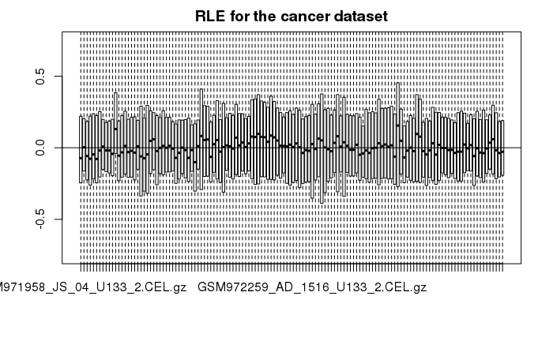

```r
RLE(Probe_Set,main="RLE for the cancer dataset")
```

we can also extract the medians from it by using the option “stats” the output from stats has medians along rows, to get it along columns we transpose the data frame and apply “as.data.frame” (not “data.frame”) to it.

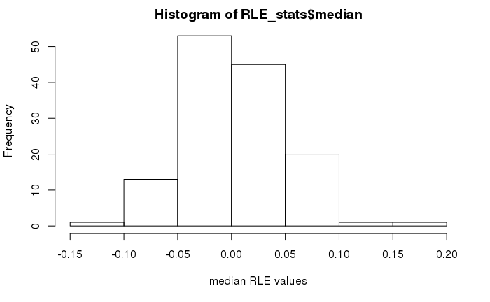

```r
RLE_stats<-data.frame(RLE(Probe_Set, type="stats"))
RLE_stats<-as.data.frame(t(RLE_stats) )
#png("/projectnb/bf528/users/group9/project1/histogram_RLE.png")
hist(RLE_stats$median, xlab="median RLE values")
```

```r
# dev.off()
```

## now calculate NUSE (Normalized Unscaled Standard Error )

the procedure is similar to RLE

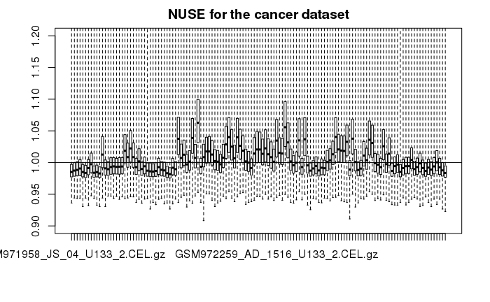

```r
NUSE(Probe_Set,main="NUSE for the cancer dataset")
```

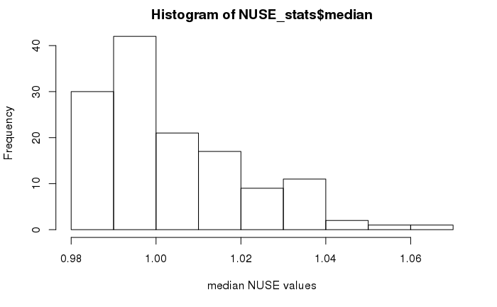

```r
NUSE_stats<-as.data.frame(t(NUSE(Probe_Set,type="stats")))
# png("/projectnb/bf528/users/group9/project1/histogram_NUSE.png")
hist(NUSE_stats$median,xlab="median NUSE values")
```

```r
#dev.off()
```

# Batch correcting using ComBat

the paper “The SVA package for removing batch effects and other unwanted variation in high-throughput experiments” by Leek et. al. introduces the way to correct for batch effects using sva package or combat. It works a little bit like comparing the linear model fit to confounders(batch variables) only which is a null model, and the linear model fit to confounders & the target variable of interest ( cancer here).

## Load metadata

```r
metadata_file='/project/bf528/project_1/doc/proj_metadata.csv'
metadata<-read.csv(metadata_file)
```

## caclulate expression matrix,and model matrix to pass to ComBat to correct for batch effects.

the model matrix is computed using the model.matrix function. it does not includes the batch variable; the batch variable is passed separarely

```r
expression_matrix<-exprs(normalized_expression) ### we need a matrix of expression x samples for ComBat
model_matrix<-model.matrix(~as.factor(normalizationcombatmod), data=metadata)
Combat_data<-ComBat(dat=expression_matrix, batch=metadata$normalizationcombatbatch,  mod =model_matrix)
write.csv(Combat_data, "/projectnb/bf528/users/group9/project1/batch_corrected_expression_values.csv")
```

# Perform PCA

```r
Combat_data_t <- t(Combat_data)
Combat_data_t <- scale(Combat_data_t)
Combat_data_scaled <- t(Combat_data_t)
pca_out <- prcomp(Combat_data_scaled, scale = FALSE, center = FALSE)
summary(pca_out) ## many principal components required to explain a finite fraction of the variance
```

```
Importance of components:
                          PC1     PC2     PC3     PC4     PC5     PC6     PC7     PC8     PC9    PC10    PC11    PC12   PC13    PC14
Standard deviation     3.9059 3.34420 2.55461 2.41429 1.83964 1.73695 1.64904 1.61192 1.60725 1.46705 1.40441 1.32697 1.2739 1.25120
Proportion of Variance 0.1147 0.08409 0.04907 0.04382 0.02545 0.02268 0.02045 0.01954 0.01942 0.01618 0.01483 0.01324 0.0122 0.01177
Cumulative Proportion  0.1147 0.19879 0.24786 0.29168 0.31713 0.33981 0.36026 0.37979 0.39921 0.41540 0.43023 0.44347 0.4557 0.46744
                          PC15    PC16    PC17    PC18    PC19    PC20    PC21    PC22    PC23    PC24    PC25    PC26    PC27    PC28
Standard deviation     1.21825 1.15962 1.15733 1.14046 1.11873 1.09174 1.09025 1.07103 1.05288 1.04236 1.03195 1.00984 0.99298 0.97919
Proportion of Variance 0.01116 0.01011 0.01007 0.00978 0.00941 0.00896 0.00894 0.00862 0.00833 0.00817 0.00801 0.00767 0.00741 0.00721
Cumulative Proportion  0.47860 0.48871 0.49878 0.50856 0.51797 0.52693 0.53586 0.54449 0.55282 0.56099 0.56900 0.57667 0.58408 0.59129
                          PC29    PC30    PC31   PC32    PC33    PC34    PC35    PC36    PC37    PC38    PC39    PC40    PC41    PC42
Standard deviation     0.96887 0.96074 0.94856 0.9436 0.93253 0.92148 0.91481 0.90668 0.90362 0.89682 0.88528 0.88259 0.87494 0.86714
Proportion of Variance 0.00706 0.00694 0.00676 0.0067 0.00654 0.00638 0.00629 0.00618 0.00614 0.00605 0.00589 0.00586 0.00576 0.00565
Cumulative Proportion  0.59835 0.60529 0.61205 0.6188 0.62529 0.63167 0.63796 0.64414 0.65028 0.65633 0.66222 0.66808 0.67384 0.67949
                          PC43   PC44    PC45    PC46    PC47    PC48    PC49    PC50    PC51    PC52    PC53    PC54    PC55    PC56
Standard deviation     0.86263 0.8553 0.84899 0.84689 0.83720 0.83457 0.82645 0.82420 0.82151 0.81800 0.81347 0.81158 0.80918 0.80195
Proportion of Variance 0.00559 0.0055 0.00542 0.00539 0.00527 0.00524 0.00514 0.00511 0.00507 0.00503 0.00498 0.00495 0.00492 0.00484
Cumulative Proportion  0.68508 0.6906 0.69600 0.70140 0.70667 0.71190 0.71704 0.72214 0.72722 0.73225 0.73723 0.74218 0.74710 0.75194
                          PC57    PC58    PC59    PC60    PC61    PC62   PC63    PC64    PC65    PC66    PC67    PC68    PC69    PC70
Standard deviation     0.78927 0.78881 0.78311 0.78124 0.77995 0.77635 0.7733 0.77013 0.76441 0.76181 0.75996 0.75833 0.75203 0.75108
Proportion of Variance 0.00468 0.00468 0.00461 0.00459 0.00457 0.00453 0.0045 0.00446 0.00439 0.00436 0.00434 0.00432 0.00425 0.00424
Cumulative Proportion  0.75662 0.76130 0.76591 0.77050 0.77507 0.77960 0.7841 0.78856 0.79295 0.79732 0.80166 0.80598 0.81023 0.81447
                          PC71    PC72    PC73   PC74    PC75    PC76    PC77    PC78    PC79    PC80    PC81    PC82    PC83    PC84
Standard deviation     0.74576 0.74280 0.74222 0.7382 0.73704 0.73325 0.72687 0.72605 0.72413 0.72118 0.71918 0.71782 0.71597 0.71297
Proportion of Variance 0.00418 0.00415 0.00414 0.0041 0.00408 0.00404 0.00397 0.00396 0.00394 0.00391 0.00389 0.00387 0.00385 0.00382
Cumulative Proportion  0.81866 0.82280 0.82695 0.8310 0.83513 0.83917 0.84314 0.84711 0.85105 0.85496 0.85885 0.86272 0.86658 0.87040
                          PC85    PC86    PC87    PC88    PC89    PC90    PC91    PC92    PC93    PC94    PC95    PC96    PC97    PC98
Standard deviation     0.71010 0.70846 0.70503 0.69861 0.69417 0.69319 0.68856 0.68609 0.68314 0.67981 0.67794 0.67468 0.66880 0.66766
Proportion of Variance 0.00379 0.00377 0.00374 0.00367 0.00362 0.00361 0.00356 0.00354 0.00351 0.00347 0.00346 0.00342 0.00336 0.00335
Cumulative Proportion  0.87419 0.87796 0.88170 0.88537 0.88899 0.89261 0.89617 0.89971 0.90322 0.90669 0.91015 0.91357 0.91694 0.92029
                          PC99   PC100   PC101   PC102   PC103   PC104   PC105   PC106   PC107   PC108   PC109   PC110   PC111   PC112
Standard deviation     0.66181 0.66005 0.65695 0.65449 0.65374 0.64993 0.64562 0.63935 0.63694 0.63462 0.62888 0.62537 0.61990 0.61759
Proportion of Variance 0.00329 0.00328 0.00324 0.00322 0.00321 0.00318 0.00313 0.00307 0.00305 0.00303 0.00297 0.00294 0.00289 0.00287
Cumulative Proportion  0.92358 0.92686 0.93010 0.93332 0.93653 0.93971 0.94284 0.94592 0.94897 0.95200 0.95497 0.95791 0.96080 0.96367
                         PC113   PC114   PC115   PC116  PC117   PC118   PC119  PC120   PC121   PC122   PC123   PC124   PC125   PC126
Standard deviation     0.61205 0.60531 0.60310 0.59405 0.5875 0.58516 0.58166 0.5770 0.56205 0.55201 0.53643 0.52938 0.51266 0.39111
Proportion of Variance 0.00282 0.00275 0.00273 0.00265 0.0026 0.00257 0.00254 0.0025 0.00238 0.00229 0.00216 0.00211 0.00198 0.00115
Cumulative Proportion  0.96648 0.96924 0.97197 0.97463 0.9772 0.97980 0.98234 0.9848 0.98722 0.98951 0.99167 0.99378 0.99576 0.99691
                         PC127   PC128   PC129   PC130   PC131   PC132   PC133     PC134
Standard deviation     0.32507 0.28113 0.26169 0.24995 0.21715 0.16548 0.14588 1.114e-14
Proportion of Variance 0.00079 0.00059 0.00051 0.00047 0.00035 0.00021 0.00016 0.000e+00
Cumulative Proportion  0.99770 0.99829 0.99881 0.99928 0.99963 0.99984 1.00000 1.000e+00
```

plot and save the PCA

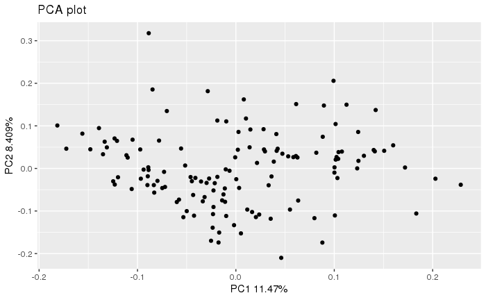

```r
rotated_pca<-as.data.frame(pca$rotation)
# png("/projectnb/bf528/users/group9/project1/PCA_plot.png")
ggplot(data = rotated_pca, mapping = aes(x = PC1, y = PC2)) +geom_point()+labs(title = 'PCA plot', x= 'PC1 11.47%', y='PC2 8.409%')
```

```r
#dev.off()
## automatic plotting doesnt work because we scaled separaely
# library(ggfortify)
# autoplot(pca_out)
# library(ggbiplot)
# ggbiplot(pca_out)
```